# Def_red_mak RESULTS

## Schmidt’s fuzzy elements

```
## [1] "USER'S ACCURACY"
```

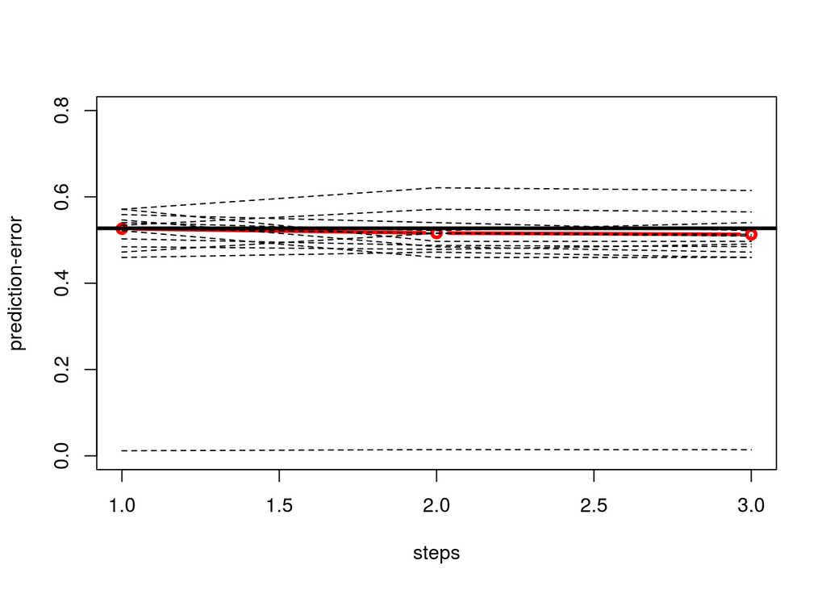

```
##                                           k 1
## 1 Fuzzylandform_res150m_ls6_hs12_R19803_R2333
## 2  Fuzzylandform_res50m_ls3_hs12_R11250_R2166
## 3 Fuzzylandform_res150m_ls6_hs21_R11666_R2200
##                                           k 2
## 1 Fuzzylandform_res150m_ls6_hs12_R19803_R2333
## 2   Fuzzylandform_res50m_ls3_hs12_R1500_R2200
## 3 Fuzzylandform_res150m_ls12_hs18_R1833_R2714
##                                           k 3
## 1 Fuzzylandform_res150m_ls6_hs12_R12500_R2500
## 2 Fuzzylandform_res50m_ls18_hs21_R11000_R2166
## 3 Fuzzylandform_res150m_ls9_hs15_R19803_R2333
##                                           k 4
## 1 Fuzzylandform_res150m_ls6_hs12_R19803_R2333
## 2   Fuzzylandform_res50m_ls3_hs15_R1555_R2200
```

[output cut: 25 more lines]

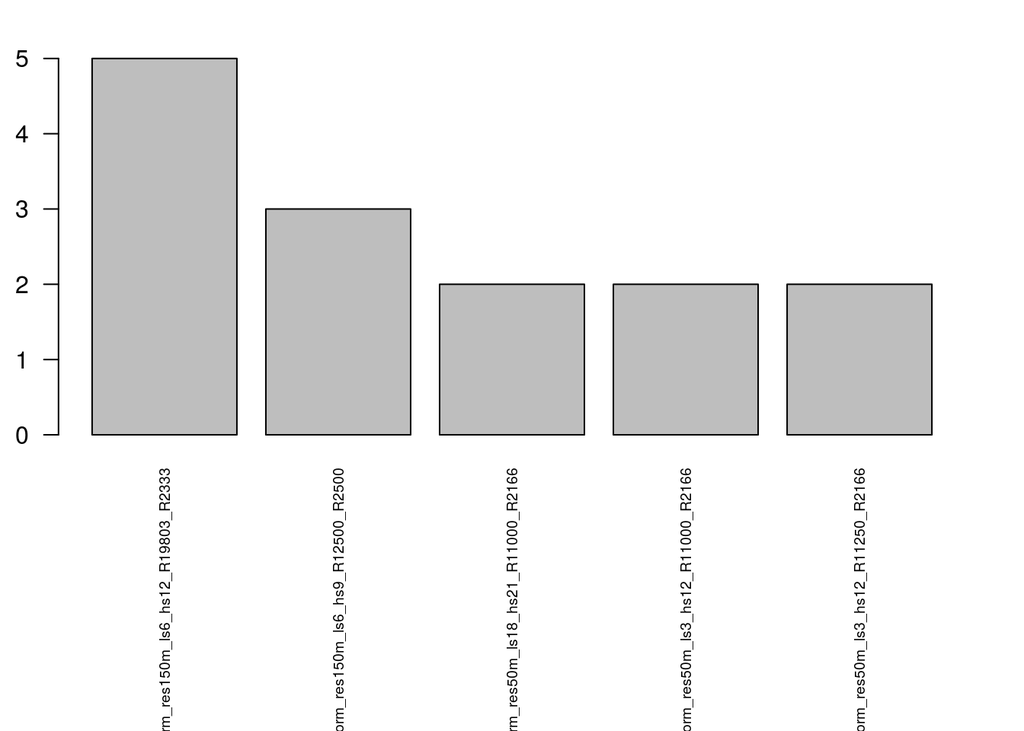

```
##                                      allchosen Freq
## 7  Fuzzylandform_res150m_ls6_hs12_R19803_R2333    5
## 9   Fuzzylandform_res150m_ls6_hs9_R12500_R2500    3
## 15 Fuzzylandform_res50m_ls18_hs21_R11000_R2166    2
## 16  Fuzzylandform_res50m_ls3_hs12_R11000_R2166    2
## 17  Fuzzylandform_res50m_ls3_hs12_R11250_R2166    2
```

```
## [1] "KAPPA"
```

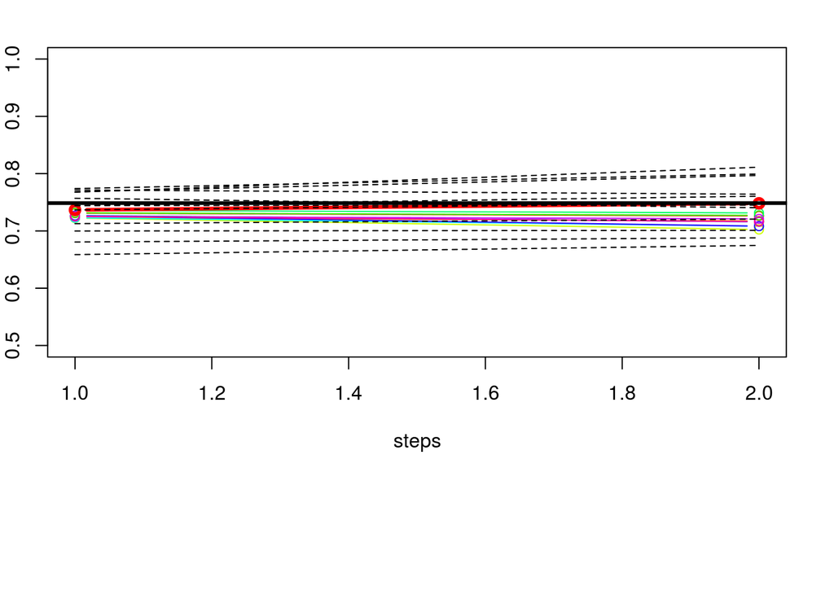

```
##                                            k 1
## 1  Fuzzylandform_res150m_ls9_hs12_R11250_R2625
## 2 Fuzzylandform_res250m_ls6_hs15_R16578_R25000
##                                           k 2
## 1 Fuzzylandform_res150m_ls9_hs18_R11250_R2625
## 2 Fuzzylandform_res150m_ls9_hs18_R19803_R2333
##                                           k 3
## 1 Fuzzylandform_res150m_ls9_hs15_R11666_R2555
## 2 Fuzzylandform_res50m_ls12_hs21_R11250_R2166
##                                             k 4
## 1   Fuzzylandform_res150m_ls9_hs15_R11666_R2555
## 2 Fuzzylandform_res250m_ls9_hs12_R119230_R21666
##                                           k 5
## 1 Fuzzylandform_res150m_ls9_hs12_R12500_R2500
## 2 Fuzzylandform_res250m_ls3_hs9_R15000_R22500
##                                           k 6
## 1 Fuzzylandform_res150m_ls9_hs12_R11250_R2625
## 2  Fuzzylandform_res50m_ls3_hs15_R16578_R2142
##                                           k 7
## 1 Fuzzylandform_res150m_ls9_hs15_R11666_R2555
## 2  Fuzzylandform_res100m_ls6_hs21_R1333_R2200
##                                             k 8
## 1   Fuzzylandform_res150m_ls9_hs15_R11250_R2625
## 2 Fuzzylandform_res50m_ls18_hs21_R1500000_R2166
##                                           k 9
## 1 Fuzzylandform_res150m_ls9_hs18_R11666_R2555
## 2   Fuzzylandform_res50m_ls3_hs12_R1250_R2142
##                                          k 10
## 1 Fuzzylandform_res150m_ls9_hs18_R11000_R2714
## 2 Fuzzylandform_res100m_ls12_hs18_R1833_R2333
```

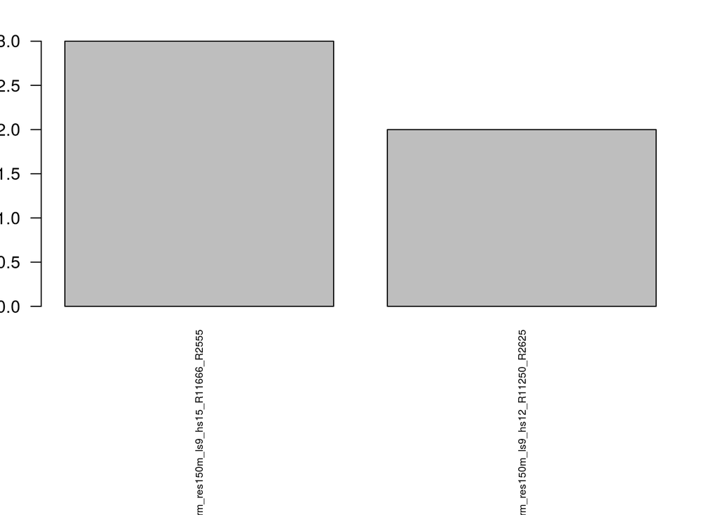

```
##                                     allchosen Freq
## 6 Fuzzylandform_res150m_ls9_hs15_R11666_R2555    3
## 3 Fuzzylandform_res150m_ls9_hs12_R11250_R2625    2
```

```
## [1] "TAU"
```

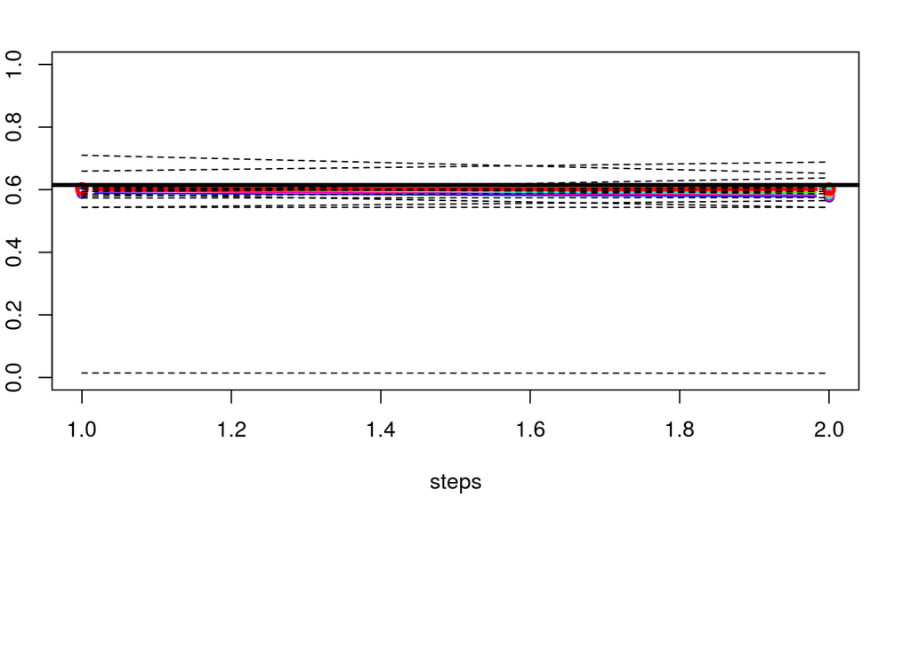

```
##                                           k 1
## 1 Fuzzylandform_res150m_ls9_hs12_R16578_R2333
## 2   Fuzzylandform_res50m_ls3_hs15_R1333_R2250
##                                           k 2
## 1 Fuzzylandform_res150m_ls9_hs12_R19803_R2333
## 2  Fuzzylandform_res50m_ls15_hs21_R1500_R2200
##                                             k 3
## 1   Fuzzylandform_res150m_ls9_hs12_R16578_R2333
## 2 Fuzzylandform_res50m_ls15_hs18_R1500000_R2142
##                                           k 4
## 1 Fuzzylandform_res150m_ls9_hs12_R16578_R2333
## 2  Fuzzylandform_res50m_ls3_hs12_R11000_R2166
##                                           k 5
## 1 Fuzzylandform_res150m_ls9_hs12_R19803_R2333
## 2   Fuzzylandform_res50m_ls3_hs12_R1500_R2200
##                                             k 6
## 1   Fuzzylandform_res150m_ls6_hs12_R19803_R2333
## 2 Fuzzylandform_res50m_ls18_hs21_R1500000_R2142
##                                           k 7
## 1 Fuzzylandform_res150m_ls6_hs12_R19803_R2333
## 2   Fuzzylandform_res50m_ls3_hs15_R1555_R2166
##                                           k 8
## 1 Fuzzylandform_res150m_ls9_hs12_R19803_R2333
## 2   Fuzzylandform_res50m_ls3_hs15_R1250_R2100
##                                            k 9
## 1  Fuzzylandform_res150m_ls9_hs12_R19803_R2333
## 2 Fuzzylandform_res50m_ls3_hs12_R1500000_R2142
##                                          k 10
## 1 Fuzzylandform_res150m_ls9_hs12_R19803_R2333
## 2 Fuzzylandform_res50m_ls18_hs21_R16578_R2142
```

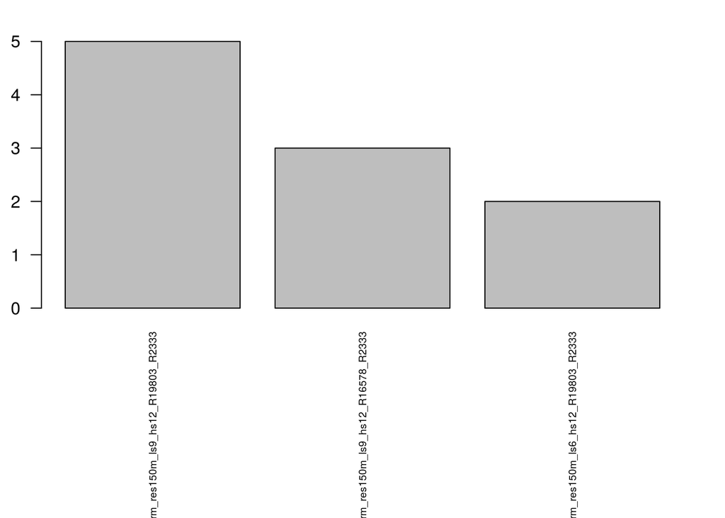

```
##                                     allchosen Freq
## 3 Fuzzylandform_res150m_ls9_hs12_R19803_R2333    5
## 2 Fuzzylandform_res150m_ls9_hs12_R16578_R2333    3
## 1 Fuzzylandform_res150m_ls6_hs12_R19803_R2333    2
```

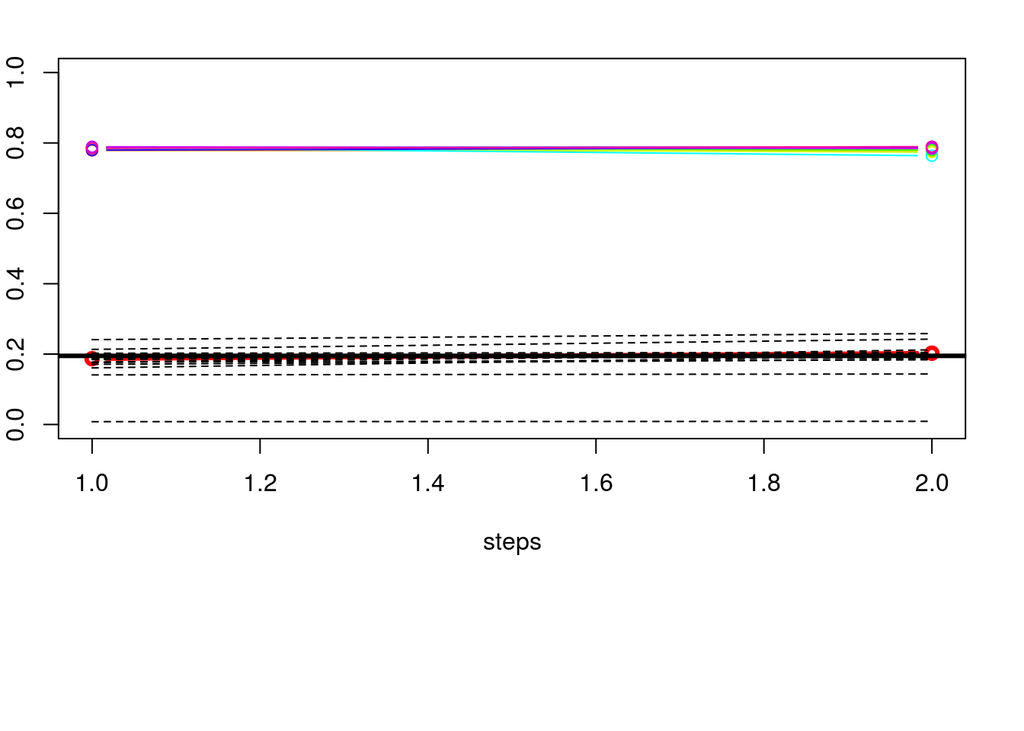

```
##                                            k 1
## 1   Fuzzylandform_res100m_ls6_hs12_R1714_R2500
## 2 Fuzzylandform_res150m_ls12_hs15_R12500_R2500
##                                             k 2
## 1 Fuzzylandform_res150m_ls9_hs12_R1500000_R2333
## 2     Fuzzylandform_res50m_ls3_hs12_R1125_R2100
##                                           k 3
## 1 Fuzzylandform_res150m_ls9_hs12_R11250_R2625
## 2   Fuzzylandform_res50m_ls3_hs12_R1555_R2200
##                                             k 4
## 1 Fuzzylandform_res150m_ls9_hs12_R1500000_R2333
## 2   Fuzzylandform_res150m_ls12_hs15_R1714_R2625
##                                           k 5
## 1 Fuzzylandform_res100m_ls3_hs12_R12500_R2333
## 2  Fuzzylandform_res150m_ls3_hs9_R11000_R2714
##                                          k 6
## 1 Fuzzylandform_res150m_ls6_hs9_R12500_R2500
## 2   Fuzzylandform_res50m_ls6_hs9_R1625_R2333
##                                           k 7
## 1 Fuzzylandform_res150m_ls9_hs12_R11250_R2714
## 2  Fuzzylandform_res100m_ls3_hs15_R1142_R2111
##                                           k 8
## 1 Fuzzylandform_res150m_ls9_hs12_R16578_R2333
## 2 Fuzzylandform_res150m_ls3_hs12_R11000_R2500
##                                           k 9
## 1 Fuzzylandform_res150m_ls9_hs12_R11250_R2714
## 2  Fuzzylandform_res50m_ls6_hs9_R119230_R2250
##                                          k 10
## 1  Fuzzylandform_res150m_ls6_hs9_R12500_R2555
## 2 Fuzzylandform_res100m_ls3_hs21_R11666_R2333
```

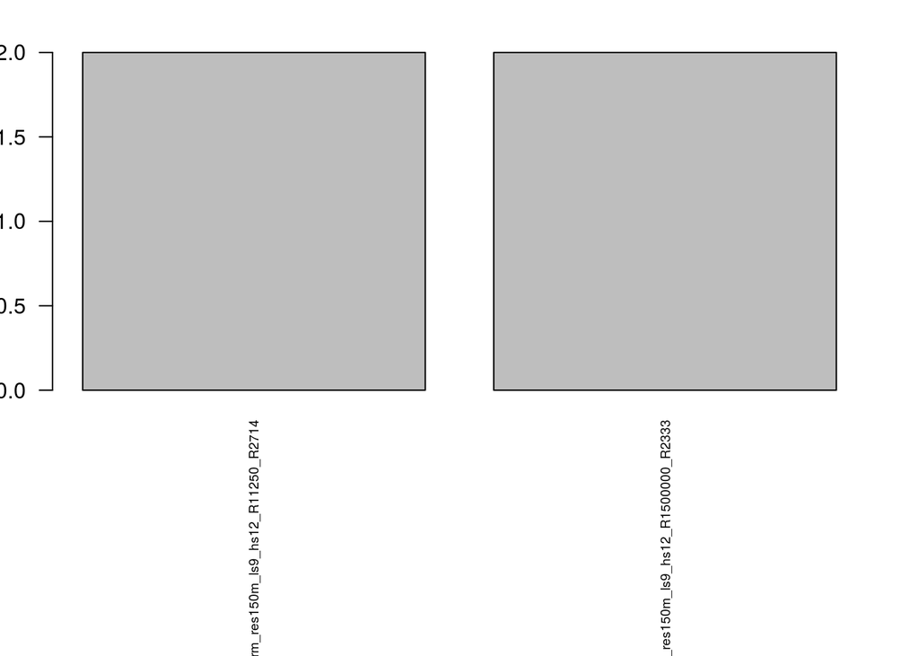

```
##                                        allchosen Freq
## 12   Fuzzylandform_res150m_ls9_hs12_R11250_R2714    2
## 13 Fuzzylandform_res150m_ls9_hs12_R1500000_R2333    2
```

- UA: one predictor sufficient (not clear): NUMBER ONE WITH 5 PICKS:Fuzzylandform_res150m_ls6_hs12_R19803_R2333
- KAPPA: one pred suffiencent:Fuzzylandform_res150m_ls9_hs15_R11666_R2555 (3x but quite representative regarding res,slope and more or less curvature)
- TAU: one sufficient: Fuzzylandform_res150m_ls9_hs12_R19803_R2333; curv thresholds are very similar!! also slope very consistent!
- QUALITY: sehr unsicher, 2x nr1 = Fuzzylandform_res150m_ls9_hs12_R11250_R2714; auch so ein bisserl ein mittelwert ist Fuzzylandform_res150m_ls6_hs9_R12500_R2500

```
## [1] "10fold cv-error:  0.516770186335404  for predictors Fuzzylandform_res150m_ls6_hs12_R19803_R2333"
##
## preds  FL  LO  DA  FS  BS  SH  RI
##    FL  21   1   5   3   3   4   8
##    LO   1  75   2  12  23   4  23
##    DA   0   0   0   0   0   0   0
##    FS   4  17   8  56  22   0  21
##    BS  25 101  31  94 515  56 231
##    SH   0   0   0   0   0   0   0
##    RI   4  14   0   8  69  35 114
## [1] Number of observations: 1610
## [1] Summary of naive statistics
## [1] Overall accuracy, stdev, CV%: 0.4851 , 0.0125 , 2.6
## [1] 95 % confidence limits for accuracy: 0.4604 ... 0.5098
## [1] User’s accuracy
##     FL     LO     DA     FS     BS     SH     RI
## 0.4667 0.5357    NaN 0.4375 0.4891    NaN 0.4672
## [1] Producer’s reliability:
##     FL     LO     DA     FS     BS     SH     RI
## 0.3818 0.3606 0.0000 0.3237 0.8149 0.0000 0.2872
## [1] Summary of kappa statistics
## [1] Overall kappa, stdev, & CV%: 0.2485 , 0.0162 , 6.5
## [1] 95 % confidence limits for kappa: 0.2164 ... 0.2805
## [1] Per-class kappa, stdev, & CV%, for user’s accuracy:
##     FL     LO     DA     FS     BS     SH     RI
## 0.4478 0.4668    NaN 0.3698 0.1589    NaN 0.2928
##     FL     LO     DA     FS     BS     SH     RI
## 0.0758 0.0464    NaN 0.0469 0.0148    NaN 0.0389
##   FL   LO   DA   FS   BS   SH   RI
## 16.9  9.9  NaN 12.7  9.3  NaN 13.3
## [1] Per-class kappa, stdev, & CV%, for producer’s reliability:
##     FL     LO     DA     FS     BS     SH     RI
## 0.3640 0.2997 0.0000 0.2653 0.4649 0.0000 0.1598
##     FL     LO     DA     FS     BS     SH     RI
## 0.0660 0.0334 0.0000 0.0359 0.0386 0.0000 0.0223
##   FL   LO   DA   FS   BS   SH   RI
## 18.1 11.2  NaN 13.5  8.3  NaN 14.0
## [1] Number of observations: 1610
## [1] Prior class probabilities:
## [1] 0.1428571 0.1428571 0.1428571 0.1428571 0.1428571 0.1428571 0.1428571
## [1] Observed class proportions:
##     FL     LO     DA     FS     BS     SH     RI
## 0.0280 0.0870 0.0000 0.0795 0.6540 0.0000 0.1516
## [1] Reference class proportions:
##     FL     LO     DA     FS     BS     SH     RI
## 0.0342 0.1292 0.0286 0.1075 0.3925 0.0615 0.2466
## [1] Tau, stdev, & CV%: 0.3993 , 0.013 , 3.3
## [1] 95% confidence limits for tau:0.3735...0.4251
## [1] "mean quality =  0.20365845912236"
## [1] "The quality of the modeled TP is  0.20365845912236"
```

```
## [1] "#########  Cramer's V =  NaN"
## [1] "###################################################################################################"
## [1] "10fold cv-error:  0.516770186335404  for predictors Fuzzylandform_res150m_ls9_hs12_R19803_R2333"
##
## preds  FL  LO  DA  FS  BS  SH  RI
##    FL  25   3   9   4   6   5  11
##    LO   1  74   2  12  23   4  22
##    DA   0   0   0   0   0   0   0
##    FS   3  17   8  56  22   0  21
##    BS  22 100  27  93 512  55 229
##    SH   1   0   0   0   3  11   5
##    RI   3  14   0   8  66  24 109
## [1] Number of observations: 1610
## [1] Summary of naive statistics
## [1] Overall accuracy, stdev, CV%: 0.4888 , 0.0125 , 2.5
## [1] 95 % confidence limits for accuracy: 0.4641 ... 0.5135
## [1] User’s accuracy
##     FL     LO     DA     FS     BS     SH     RI
## 0.3968 0.5362    NaN 0.4409 0.4933 0.5500 0.4866
## [1] Producer’s reliability:
##     FL     LO     DA     FS     BS     SH     RI
## 0.4545 0.3558 0.0000 0.3237 0.8101 0.1111 0.2746
## [1] Summary of kappa statistics
## [1] Overall kappa, stdev, & CV%: 0.2602 , 0.0163 , 6.2
## [1] 95 % confidence limits for kappa: 0.228 ... 0.2924
## [1] Per-class kappa, stdev, & CV%, for user’s accuracy:
##     FL     LO     DA     FS     BS     SH     RI
## 0.3755 0.4674    NaN 0.3736 0.1658 0.5205 0.3186
##     FL     LO     DA     FS     BS     SH     RI
## 0.0623 0.0468    NaN 0.0472 0.0152 0.1179 0.0411
##   FL   LO   DA   FS   BS   SH   RI
## 16.6 10.0  NaN 12.6  9.1 22.6 12.9
## [1] Per-class kappa, stdev, & CV%, for producer’s reliability:
##     FL     LO     DA     FS     BS     SH     RI
## 0.4323 0.2954 0.0000 0.2658 0.4656 0.0999 0.1573
##     FL     LO     DA     FS     BS     SH     RI
## 0.0686 0.0333 0.0000 0.0358 0.0380 0.0303 0.0216
##   FL   LO   DA   FS   BS   SH   RI
## 15.9 11.3  NaN 13.5  8.2 30.3 13.7
## [1] Number of observations: 1610
## [1] Prior class probabilities:
## [1] 0.1428571 0.1428571 0.1428571 0.1428571 0.1428571 0.1428571 0.1428571
## [1] Observed class proportions:
##     FL     LO     DA     FS     BS     SH     RI
## 0.0391 0.0857 0.0000 0.0789 0.6447 0.0124 0.1391
## [1] Reference class proportions:
##     FL     LO     DA     FS     BS     SH     RI
## 0.0342 0.1292 0.0286 0.1075 0.3925 0.0615 0.2466
## [1] Tau, stdev, & CV%: 0.4036 , 0.013 , 3.2
## [1] 95% confidence limits for tau:0.3778...0.4295
## [1] "mean quality =  0.218181189270346"
## [1] "The quality of the modeled TP is  0.218181189270346"
```

```
## [1] "#########  Cramer's V =  NaN"
## [1] "###################################################################################################"
## [1] "10fold cv-error:  0.529813664596273  for predictors Fuzzylandform_res150m_ls9_hs12_R11250_R2714"
##
## preds  FL  LO  DA  FS  BS  SH  RI
##    FL  25   3   9   4   6   5  11
##    LO   2  91   4  20  41   5  36
##    DA   0   0   0   0   0   0   0
##    FS   4  15   8  67  42   2  23
##    BS  15  78  22  65 417  41 164
##    SH   0   0   0   0   0   0   0
##    RI   9  21   3  17 126  46 163
## [1] Number of observations: 1610
## [1] Summary of naive statistics
## [1] Overall accuracy, stdev, CV%: 0.4739 , 0.0124 , 2.6
## [1] 95 % confidence limits for accuracy: 0.4492 ... 0.4986
## [1] User’s accuracy
##     FL     LO     DA     FS     BS     SH     RI
## 0.3968 0.4573    NaN 0.4161 0.5200    NaN 0.4234
## [1] Producer’s reliability:
##     FL     LO     DA     FS     BS     SH     RI
## 0.4545 0.4375 0.0000 0.3873 0.6598 0.0000 0.4106
## [1] Summary of kappa statistics
## [1] Overall kappa, stdev, & CV%: 0.2667 , 0.0167 , 6.2
## [1] 95 % confidence limits for kappa: 0.2337 ... 0.2997
## [1] Per-class kappa, stdev, & CV%, for user’s accuracy:
##     FL     LO     DA     FS     BS     SH     RI
## 0.3755 0.3768    NaN 0.3459 0.2097    NaN 0.2347
##     FL     LO     DA     FS     BS     SH     RI
## 0.0623 0.0378    NaN 0.0410 0.0207    NaN 0.0288
##   FL   LO   DA   FS   BS   SH   RI
## 16.6 10.0  NaN 11.8  9.9  NaN 12.3
## [1] Per-class kappa, stdev, & CV%, for producer’s reliability:
##     FL     LO     DA     FS     BS     SH     RI
## 0.4323 0.3582 0.0000 0.3192 0.3221 0.0000 0.2253
##     FL     LO     DA     FS     BS     SH     RI
## 0.0686 0.0363 0.0000 0.0384 0.0307 0.0000 0.0277
##   FL   LO   DA   FS   BS   SH   RI
## 15.9 10.1  NaN 12.0  9.5  NaN 12.3
## [1] Number of observations: 1610
## [1] Prior class probabilities:
## [1] 0.1428571 0.1428571 0.1428571 0.1428571 0.1428571 0.1428571 0.1428571
## [1] Observed class proportions:
##     FL     LO     DA     FS     BS     SH     RI
## 0.0391 0.1236 0.0000 0.1000 0.4981 0.0000 0.2391
## [1] Reference class proportions:
##     FL     LO     DA     FS     BS     SH     RI
## 0.0342 0.1292 0.0286 0.1075 0.3925 0.0615 0.2466
## [1] Tau, stdev, & CV%: 0.3862 , 0.0132 , 3.4
## [1] 95% confidence limits for tau:0.3601...0.4123
## [1] "mean quality =  0.211583666323169"
## [1] "The quality of the modeled TP is  0.211583666323169"
```

```
## [1] "#########  Cramer's V =  NaN"
## [1] "###################################################################################################"
```

## TPI-based landform classification

```
## [1] "USER'S ACCURACY"
```

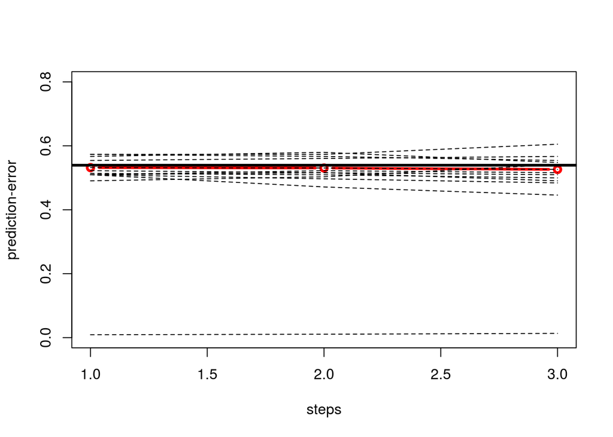

```
##                          k 1                        k 2
## 1 TPI_landforms_r100R300_10m TPI_landforms_r100R350_10m
## 2  TPI_landforms_r80R350_10m    TPI_landforms_r500R1500
## 3    TPI_landforms_r150R1550  TPI_landforms_r80R200_10m
##                         k 3                        k 4
## 1 TPI_landforms_r70R250_10m TPI_landforms_r100R350_10m
## 2 TPI_landforms_r70R400_10m  TPI_landforms_r20R200_10m
## 3    TPI_landforms_r50R2000     TPI_landforms_r50R1950
##                          k 5                       k 6
## 1 TPI_landforms_r100R350_10m TPI_landforms_r70R250_10m
## 2  TPI_landforms_r80R250_10m TPI_landforms_r70R400_10m
## 3     TPI_landforms_r50R1950   TPI_landforms_r400R1500
##                         k 7                        k 8
## 1 TPI_landforms_r60R350_10m  TPI_landforms_r70R350_10m
## 2 TPI_landforms_r80R200_10m  TPI_landforms_r100R50_10m
## 3   TPI_landforms_r150R1950 TPI_landforms_r100R250_10m
##                         k 9                      k 10
## 1 TPI_landforms_r70R250_10m TPI_landforms_r70R250_10m
## 2 TPI_landforms_r60R400_10m    TPI_landforms_r150R750
## 3   TPI_landforms_r300R1700  TPI_landforms_r50R50_10m
```

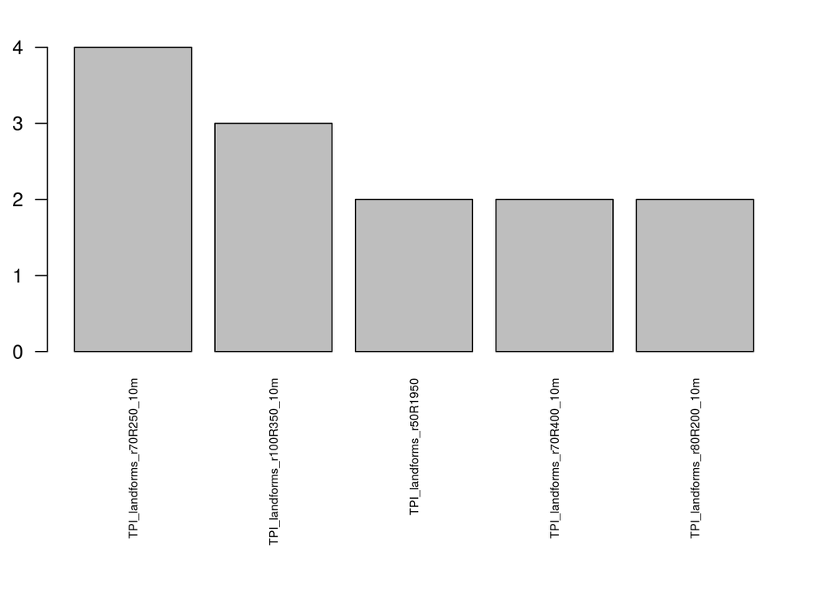

```
##                     allchosen Freq
## 17  TPI_landforms_r70R250_10m    4
## 3  TPI_landforms_r100R350_10m    3
## 12     TPI_landforms_r50R1950    2
## 19  TPI_landforms_r70R400_10m    2
## 20  TPI_landforms_r80R200_10m    2
```

```
## [1] "KAPPA"
```

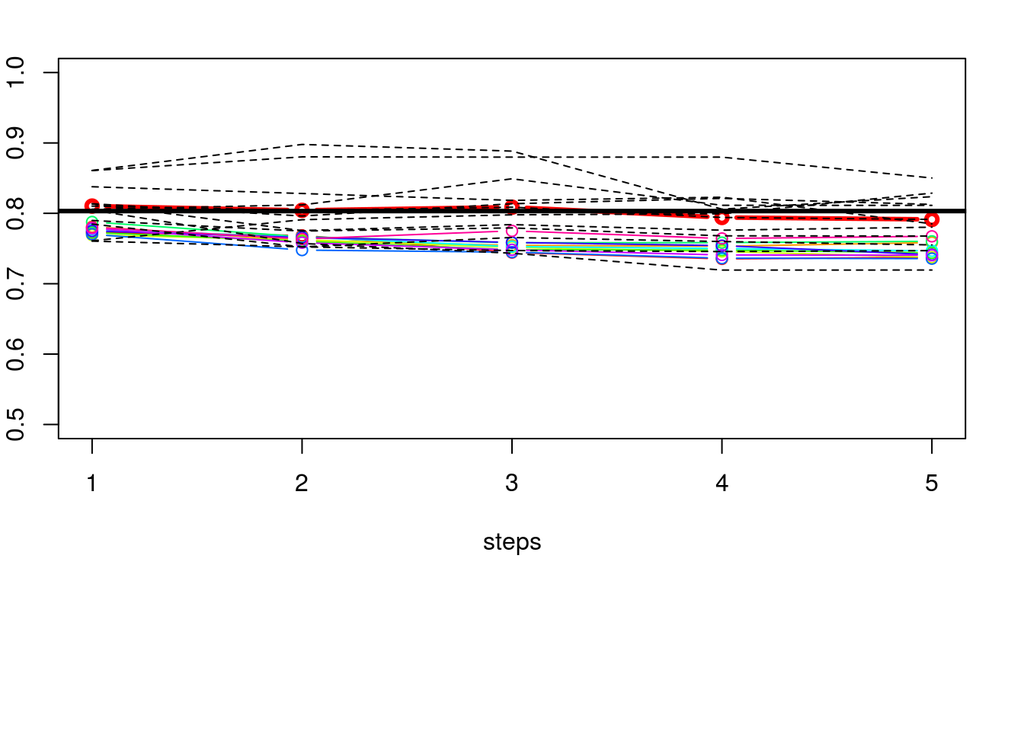

```
##                         k 1                       k 2
## 1   TPI_landforms_r150R1450 TPI_landforms_r70R450_10m
## 2    TPI_landforms_r50R1950  TPI_landforms_r1400R2000
## 3 TPI_landforms_r90R300_10m TPI_landforms_r80R100_10m
## 4  TPI_landforms_r50R50_10m   TPI_landforms_r200R2000
## 5  TPI_landforms_r1000R1400    TPI_landforms_r50R1850
##                         k 3                        k 4
## 1   TPI_landforms_r150R1700  TPI_landforms_r80R450_10m
## 2    TPI_landforms_r50R2000     TPI_landforms_r50R1550
## 3  TPI_landforms_r20R50_10m TPI_landforms_r120R400_10m
## 4 TPI_landforms_r90R400_10m TPI_landforms_r120R150_10m
## 5   TPI_landforms_r800R1700     TPI_landforms_r500R600
##                          k 5                       k 6
## 1     TPI_landforms_r150R600 TPI_landforms_r70R400_10m
## 2  TPI_landforms_r40R300_10m   TPI_landforms_r700R1400
## 3 TPI_landforms_r100R100_10m TPI_landforms_r40R100_10m
## 4     TPI_landforms_r150R650 TPI_landforms_r90R450_10m
## 5     TPI_landforms_r100R650   TPI_landforms_r600R1200
##                         k 7                       k 8
## 1   TPI_landforms_r150R1450   TPI_landforms_r150R1400
## 2 TPI_landforms_r80R200_10m   TPI_landforms_r150R1950
## 3  TPI_landforms_r50R50_10m TPI_landforms_r40R350_10m
## 4  TPI_landforms_r1500R1800  TPI_landforms_r1100R1400
## 5    TPI_landforms_r50R1950  TPI_landforms_r50R50_10m
##                          k 9                     k 10
## 1    TPI_landforms_r150R1450  TPI_landforms_r150R1850
## 2  TPI_landforms_r60R150_10m   TPI_landforms_r300R750
## 3 TPI_landforms_r100R100_10m  TPI_landforms_r100R1950
## 4    TPI_landforms_r800R1400   TPI_landforms_r300R650
## 5    TPI_landforms_r600R2000 TPI_landforms_r1500R1900
```

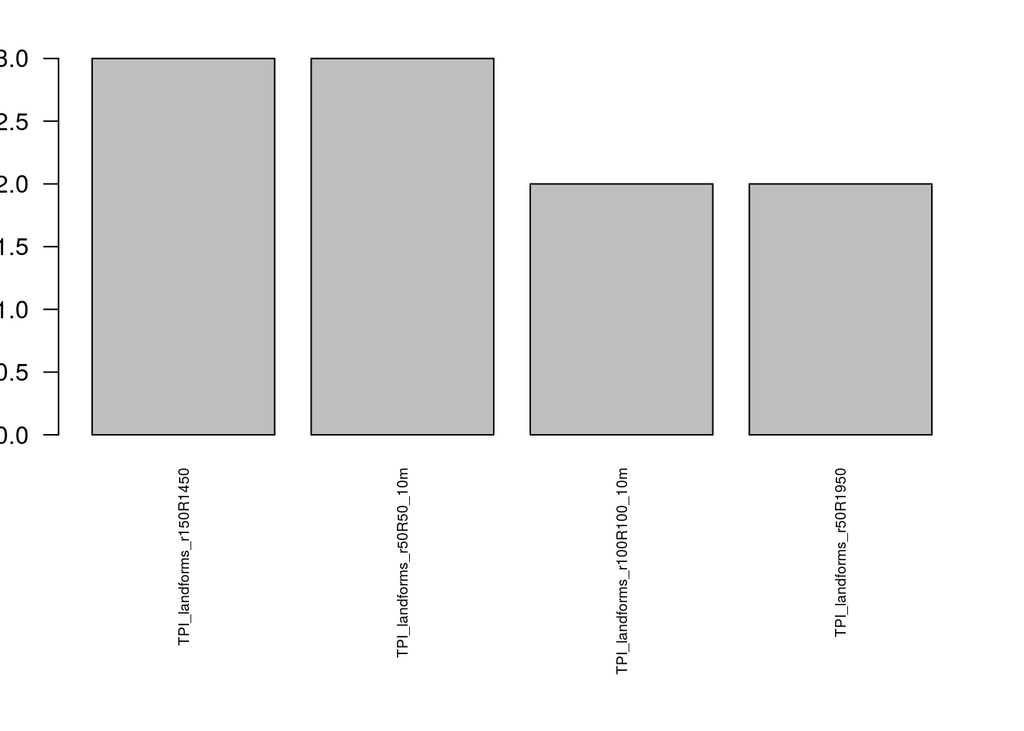

```
##                     allchosen Freq
## 12    TPI_landforms_r150R1450    3
## 30   TPI_landforms_r50R50_10m    3
## 2  TPI_landforms_r100R100_10m    2
## 28     TPI_landforms_r50R1950    2
```

```
## [1] "TAU"
```

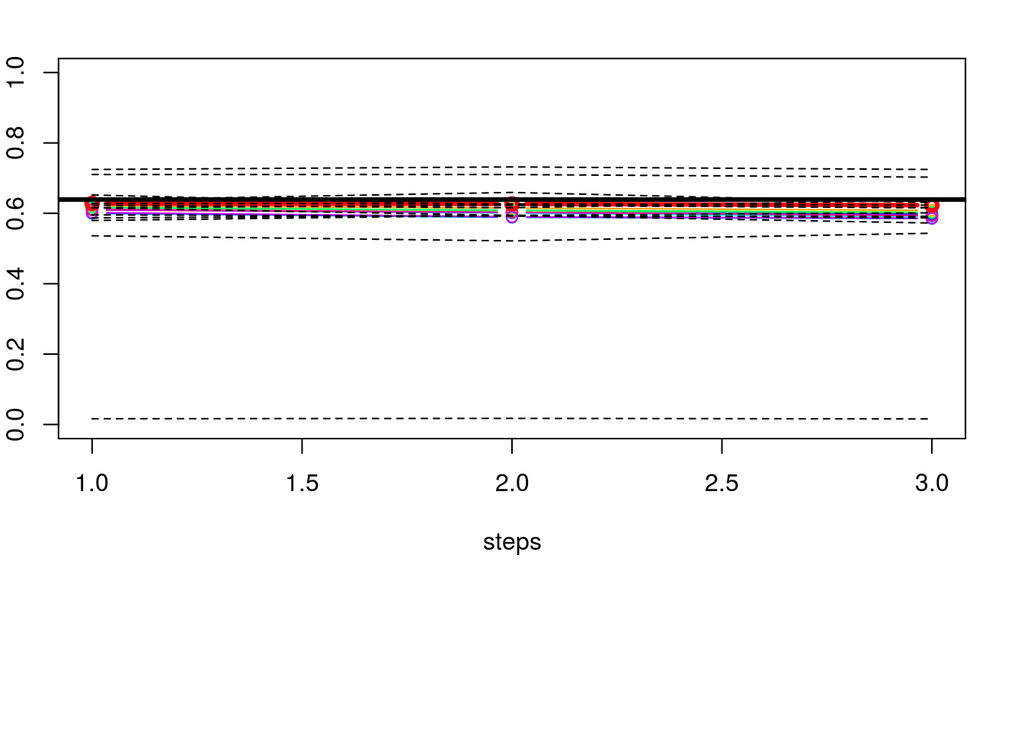

```
##                         k 1                        k 2
## 1 TPI_landforms_r60R350_10m TPI_landforms_r100R350_10m
## 2 TPI_landforms_r90R400_10m  TPI_landforms_r80R200_10m
## 3    TPI_landforms_r50R1950   TPI_landforms_r1400R1500
##                          k 3                       k 4
## 1  TPI_landforms_r80R350_10m TPI_landforms_r70R250_10m
## 2 TPI_landforms_r100R200_10m TPI_landforms_r80R400_10m
## 3    TPI_landforms_r500R1000   TPI_landforms_r500R1200
##                          k 5                        k 6
## 1  TPI_landforms_r60R250_10m  TPI_landforms_r60R350_10m
## 2    TPI_landforms_r500R1500    TPI_landforms_r150R1100
## 3 TPI_landforms_r100R400_10m TPI_landforms_r100R200_10m
##                          k 7                        k 8
## 1  TPI_landforms_r70R400_10m TPI_landforms_r100R300_10m
## 2 TPI_landforms_r100R250_10m  TPI_landforms_r70R400_10m
## 3     TPI_landforms_r50R1750  TPI_landforms_r10R250_10m
##                         k 9                      k 10
## 1 TPI_landforms_r80R350_10m TPI_landforms_r70R250_10m
## 2  TPI_landforms_r1200R1900 TPI_landforms_r90R450_10m
## 3 TPI_landforms_r80R450_10m    TPI_landforms_r50R1700
```

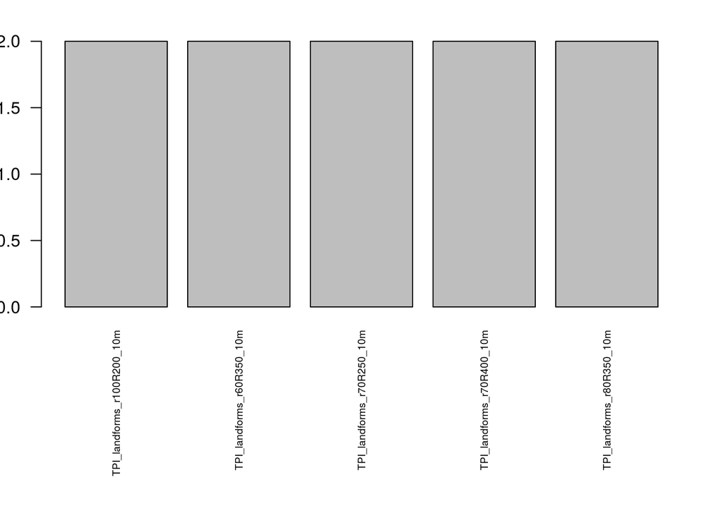

```
##                     allchosen Freq
## 1  TPI_landforms_r100R200_10m    2
## 17  TPI_landforms_r60R350_10m    2
## 18  TPI_landforms_r70R250_10m    2
## 19  TPI_landforms_r70R400_10m    2
## 21  TPI_landforms_r80R350_10m    2
```

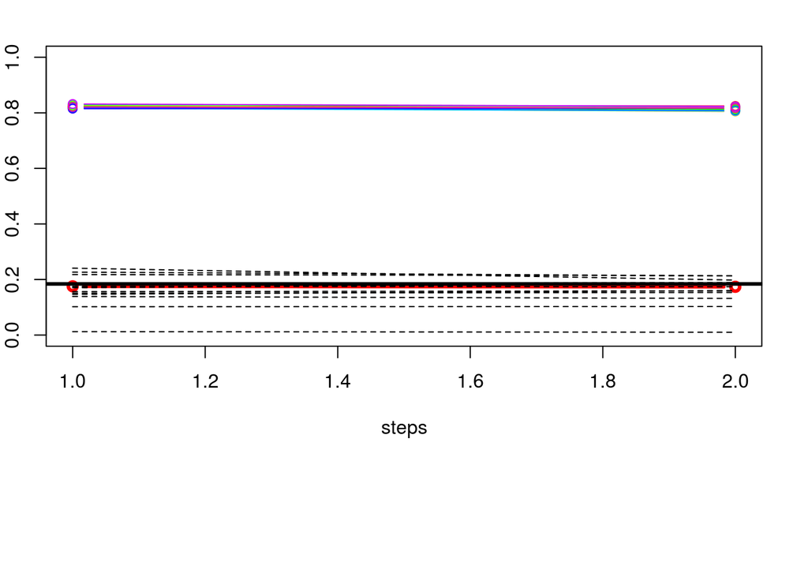

```
##                         k 1                        k 2
## 1     TPI_landforms_r50R600     TPI_landforms_r150R550
## 2 TPI_landforms_r40R150_10m TPI_landforms_r100R100_10m
##                          k 3                        k 4
## 1     TPI_landforms_r150R600 TPI_landforms_r140R450_10m
## 2 TPI_landforms_r100R100_10m   TPI_landforms_r50R50_10m
##                        k 5                      k 6
## 1   TPI_landforms_r150R600   TPI_landforms_r150R600
## 2 TPI_landforms_r50R50_10m TPI_landforms_r50R50_10m
##                        k 7                       k 8
## 1  TPI_landforms_r150R1400    TPI_landforms_r150R600
## 2 TPI_landforms_r50R50_10m TPI_landforms_r120R50_10m
##                          k 9                       k 10
## 1  TPI_landforms_r70R450_10m TPI_landforms_r140R450_10m
## 2 TPI_landforms_r100R100_10m  TPI_landforms_r70R450_10m
```

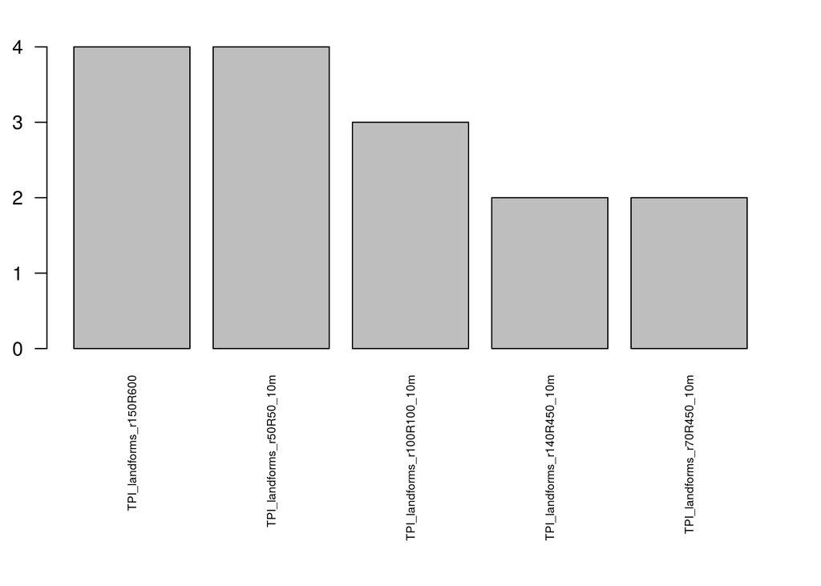

```
##                     allchosen Freq
## 6      TPI_landforms_r150R600    4
## 8    TPI_landforms_r50R50_10m    4
## 1  TPI_landforms_r100R100_10m    3
## 3  TPI_landforms_r140R450_10m    2
## 10  TPI_landforms_r70R450_10m    2
```

```
## [1] "10fold cv-error:  0.524844720496894  for predictors TPI_landforms_r70R250_10m"
##
## preds  FL  LO  DA  FS  BS  SH  RI
##    FL  14   0   0   1   0   1   2
##    LO   4  88   5  39  32   6  17
##    DA   0   0   0   0   0   0   0
##    FS   0   0   0   0   0   0   0
##    BS  32 108  40 127 555  56 270
##    SH   0   0   0   0   0   0   0
##    RI   5  12   1   6  45  36 108
## [1] Number of observations: 1610
## [1] Summary of naive statistics
## [1] Overall accuracy, stdev, CV%: 0.4752 , 0.0124 , 2.6
## [1] 95 % confidence limits for accuracy: 0.4505 ... 0.4999
## [1] User’s accuracy
##     FL     LO     DA     FS     BS     SH     RI
## 0.7778 0.4607    NaN    NaN 0.4672    NaN 0.5070
## [1] Producer’s reliability:
##     FL     LO     DA     FS     BS     SH     RI
## 0.2545 0.4231 0.0000 0.0000 0.8782 0.0000 0.2720
## [1] Summary of kappa statistics
## [1] Overall kappa, stdev, & CV%: 0.2072 , 0.0151 , 7.3
## [1] 95 % confidence limits for kappa: 0.1773 ... 0.2371
## [1] Per-class kappa, stdev, & CV%, for user’s accuracy:
##     FL     LO     DA     FS     BS     SH     RI
## 0.7699 0.3807    NaN    NaN 0.1228    NaN 0.3457
##     FL     LO     DA     FS     BS     SH     RI
## 0.1012 0.0387    NaN    NaN 0.0119    NaN 0.0424
##   FL   LO   DA   FS   BS   SH   RI
## 13.1 10.2  NaN  NaN  9.7  NaN 12.3
## [1] Per-class kappa, stdev, & CV%, for producer’s reliability:
##     FL     LO     DA     FS     BS     SH     RI
## 0.2461 0.3454 0.0000 0.0000 0.5352 0.0000 0.1610
##     FL     LO     DA     FS     BS     SH     RI
## 0.0579 0.0359 0.0000 0.0000 0.0441 0.0000 0.0213
##   FL   LO   DA   FS   BS   SH   RI
## 23.5 10.4  NaN  NaN  8.2  NaN 13.2
## [1] Number of observations: 1610
## [1] Prior class probabilities:
## [1] 0.1428571 0.1428571 0.1428571 0.1428571 0.1428571 0.1428571 0.1428571
## [1] Observed class proportions:
##     FL     LO     DA     FS     BS     SH     RI
## 0.0112 0.1186 0.0000 0.0000 0.7379 0.0000 0.1323
## [1] Reference class proportions:
##     FL     LO     DA     FS     BS     SH     RI
## 0.0342 0.1292 0.0286 0.1075 0.3925 0.0615 0.2466
## [1] Tau, stdev, & CV%: 0.3877 , 0.0129 , 3.3
## [1] 95% confidence limits for tau:0.3621...0.4133
## [1] "mean quality =  0.167731565006689"
## [1] "The quality of the modeled TP is  0.167731565006689"
```

```
## [1] "#########  Cramer's V =  NaN"
## [1] "###################################################################################################"
## [1] "10fold cv-error:  0.552173913043478  for predictors TPI_landforms_r150R1450"
##
## preds  FL  LO  DA  FS  BS  SH  RI
##    FL  10   0   0   1   0   1   3
##    LO   4  64   4  26  27   3  12
##    DA   0   0   0   0   0   0   0
##    FS   7  29  19  72  68   0  42
##    BS  28 103  22  72 483  50 230
##    SH   0   0   0   0   0   0   0
##    RI   6  12   1   2  54  45 110
## [1] Number of observations: 1610
## [1] Summary of naive statistics
## [1] Overall accuracy, stdev, CV%: 0.459 , 0.0124 , 2.7
## [1] 95 % confidence limits for accuracy: 0.4344 ... 0.4837
## [1] User’s accuracy
##     FL     LO     DA     FS     BS     SH     RI
## 0.6667 0.4571    NaN 0.3038 0.4889    NaN 0.4783
## [1] Producer’s reliability:
##     FL     LO     DA     FS     BS     SH     RI
## 0.1818 0.3077 0.0000 0.4162 0.7642 0.0000 0.2771
## [1] Summary of kappa statistics
## [1] Overall kappa, stdev, & CV%: 0.2233 , 0.0158 , 7.1
## [1] 95 % confidence limits for kappa: 0.192 ... 0.2546
## [1] Per-class kappa, stdev, & CV%, for user’s accuracy:
##     FL     LO     DA     FS     BS     SH     RI
## 0.6549 0.3766    NaN 0.2200 0.1586    NaN 0.3075
##     FL     LO     DA     FS     BS     SH     RI
## 0.1256 0.0460    NaN 0.0301 0.0162    NaN 0.0404
##   FL   LO   DA   FS   BS   SH   RI
## 19.2 12.2  NaN 13.7 10.2  NaN 13.1
## [1] Per-class kappa, stdev, & CV%, for producer’s reliability:
##     FL     LO     DA     FS     BS     SH     RI
## 0.1741 0.2418 0.0000 0.3154 0.3898 0.0000 0.1566
##     FL     LO     DA     FS     BS     SH     RI
## 0.0510 0.0320 0.0000 0.0412 0.0369 0.0000 0.0218
##   FL   LO   DA   FS   BS   SH   RI
## 29.3 13.2  NaN 13.1  9.5  NaN 13.9
## [1] Number of observations: 1610
## [1] Prior class probabilities:
## [1] 0.1428571 0.1428571 0.1428571 0.1428571 0.1428571 0.1428571 0.1428571
## [1] Observed class proportions:
##     FL     LO     DA     FS     BS     SH     RI
## 0.0093 0.0870 0.0000 0.1472 0.6137 0.0000 0.1429
## [1] Reference class proportions:
##     FL     LO     DA     FS     BS     SH     RI
## 0.0342 0.1292 0.0286 0.1075 0.3925 0.0615 0.2466
## [1] Tau, stdev, & CV%: 0.3688 , 0.013 , 3.5
## [1] 95% confidence limits for tau:0.343...0.3947
## [1] "mean quality =  0.17751494272668"
## [1] "The quality of the modeled TP is  0.17751494272668"
```

```
## [1] "#########  Cramer's V =  NaN"
## [1] "###################################################################################################"
## [1] "10fold cv-error:  0.53416149068323  for predictors TPI_landforms_r150R600"
##
## preds  FL  LO  DA  FS  BS  SH  RI
##    FL  12   0   0   1   0   1   3
##    LO   4  64   4  26  28   4  12
##    DA   0   0   0   0   0   0   0
##    FS   3  28  10  46  35   0  23
##    BS  32 106  31  98 518  47 249
##    SH   0   0   0   0   0   0   0
##    RI   4  10   1   2  51  47 110
## [1] Number of observations: 1610
## [1] Summary of naive statistics
## [1] Overall accuracy, stdev, CV%: 0.4658 , 0.0124 , 2.7
## [1] 95 % confidence limits for accuracy: 0.4412 ... 0.4905
## [1] User’s accuracy
##     FL     LO     DA     FS     BS     SH     RI
## 0.7059 0.4507    NaN 0.3172 0.4792    NaN 0.4889
## [1] Producer’s reliability:
##     FL     LO     DA     FS     BS     SH     RI
## 0.2182 0.3077 0.0000 0.2659 0.8196 0.0000 0.2771
## [1] Summary of kappa statistics
## [1] Overall kappa, stdev, & CV%: 0.2151 , 0.0156 , 7.3
## [1] 95 % confidence limits for kappa: 0.1841 ... 0.246
## [1] Per-class kappa, stdev, & CV%, for user’s accuracy:
##     FL     LO     DA     FS     BS     SH     RI
## 0.6955 0.3692    NaN 0.2350 0.1426    NaN 0.3216
##     FL     LO     DA     FS     BS     SH     RI
## 0.1141 0.0456    NaN 0.0407 0.0142    NaN 0.0410
##   FL   LO   DA   FS   BS   SH   RI
## 16.4 12.4  NaN 17.3  9.9  NaN 12.7
## [1] Per-class kappa, stdev, & CV%, for producer’s reliability:
##     FL     LO     DA     FS     BS     SH     RI
## 0.2098 0.2407 0.0000 0.1932 0.4510 0.0000 0.1596
##     FL     LO     DA     FS     BS     SH     RI
## 0.0548 0.0320 0.0000 0.0342 0.0402 0.0000 0.0217
##   FL   LO   DA   FS   BS   SH   RI
## 26.1 13.3  NaN 17.7  8.9  NaN 13.6
## [1] Number of observations: 1610
## [1] Prior class probabilities:
## [1] 0.1428571 0.1428571 0.1428571 0.1428571 0.1428571 0.1428571 0.1428571
## [1] Observed class proportions:
##     FL     LO     DA     FS     BS     SH     RI
## 0.0106 0.0882 0.0000 0.0901 0.6714 0.0000 0.1398
## [1] Reference class proportions:
##     FL     LO     DA     FS     BS     SH     RI
## 0.0342 0.1292 0.0286 0.1075 0.3925 0.0615 0.2466
## [1] Tau, stdev, & CV%: 0.3768 , 0.013 , 3.4
## [1] 95% confidence limits for tau:0.3511...0.4025
## [1] "mean quality =  0.17731577488319"
## [1] "The quality of the modeled TP is  0.17731577488319"
```

```
## [1] "#########  Cramer's V =  NaN"
## [1] "###################################################################################################"
```